# Thermal performance: CFUs and growth curves time-to-detection analyses

# Check fluorescent markers

For P. putida we have 1 sample that does not have any fluorescent marker (BSC010: P. putida mt-2 KT2440) and 4 samples that **do** have fluorescent markers (including 2 samples that are more closely related, BSC002: P. putida KT2440 and BSC015: P. putida KT2440).

First compare using the growth curve summary data for growth rate (mu):

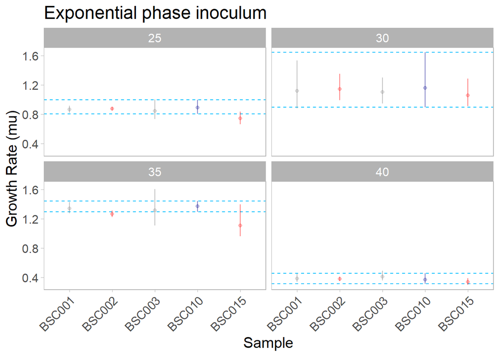

```r
# plot whether the confidence interval of BSC010 is overlapping with the other samples
ggplot(Dil_growthrates.df %>%
         filter(Inoculum == "Exponential",
                Sample %in% c(paste0("BSC00", 1:3),
                              paste0("BSC0", c(10,15)))),
       aes(x = Sample, y = mu,
           color = Sample)) +
  facet_wrap(vars(Temp)) +
  # add horizontal dashed lines for BSC010 CIs
  geom_hline(data = Dil_growthrates.df %>%
               filter(Inoculum == "Exponential",
                      Sample == "BSC010"),
             aes(yintercept = mu_lwrCI),
             linetype = "dashed", color = "deepskyblue") +
  geom_hline(data = Dil_growthrates.df %>%
               filter(Inoculum == "Exponential",
                      Sample == "BSC010"),
             aes(yintercept = mu_uprCI),
             linetype = "dashed", color = "deepskyblue") +
  # add data points and their confidence intervals on top
  geom_point(alpha = 0.25, na.rm = TRUE) +
  geom_linerange(aes(ymin = mu_lwrCI, ymax = mu_uprCI),
                 alpha = 0.5, na.rm = TRUE, linetype = "solid") +
  scale_color_manual(values = c("BSC010" = "blue4",
                                  "BSC002" = "red",
                                  "BSC015" = "red"),
                       guide = "none") +
  labs(y = "Growth Rate (mu)",
       title = "Exponential phase inoculum") +
  theme(axis.text.x = element_text(angle = 45, vjust = 1, hjust = 1),
        legend.position = "none")
```

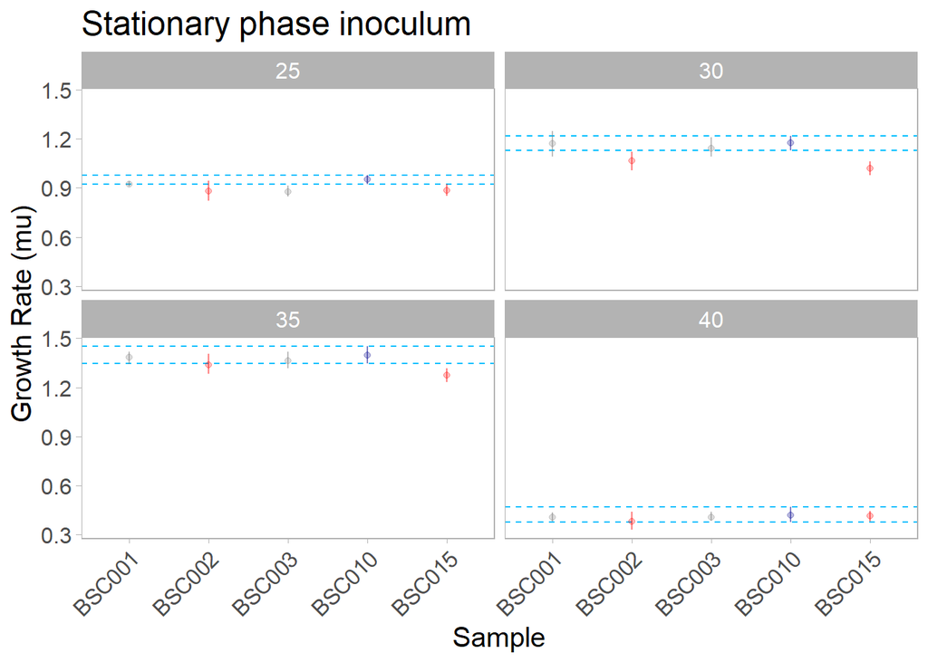

```r
ggplot(Dil_growthrates.df %>%
         filter(Inoculum == "Stationary",
                Sample %in% c(paste0("BSC00", 1:3),
                              paste0("BSC0", c(10,15)))),
       aes(x = Sample, y = mu,
           color = Sample)) +
  facet_wrap(vars(Temp)) +
  # add horizontal dashed lines for BSC010 CIs
  geom_hline(data = Dil_growthrates.df %>%
               filter(Inoculum == "Stationary",
                      Sample == "BSC010"),
             aes(yintercept = mu_lwrCI),
             linetype = "dashed", color = "deepskyblue") +
  geom_hline(data = Dil_growthrates.df %>%
               filter(Inoculum == "Stationary",
                      Sample == "BSC010"),
             aes(yintercept = mu_uprCI),
             linetype = "dashed", color = "deepskyblue") +
  # add data points and their confidence intervals on top
  geom_point(alpha = 0.25, na.rm = TRUE) +
  geom_linerange(aes(ymin = mu_lwrCI, ymax = mu_uprCI),
                 alpha = 0.5, na.rm = TRUE, linetype = "solid") +
  scale_color_manual(values = c("BSC010" = "blue4",
                                  "BSC002" = "red",
                                  "BSC015" = "red"),
                       guide = "none") +
  labs(y = "Growth Rate (mu)",
       title = "Stationary phase inoculum") +
  theme(axis.text.x = element_text(angle = 45, vjust = 1, hjust = 1),
        legend.position = "none")
```

```r
# check numerically to make sure that the confidence intervals are indeed overlapping
Dil_growthrates.df %>%
    filter(Sample %in% c("BSC010", "BSC002", "BSC015")) %>%
    group_by(Temp, Inoculum) %>%
    reframe(
        test_condition = {
            lwr010 <- mu_lwrCI[Sample == "BSC010"]
            upr010 <- mu_uprCI[Sample == "BSC010"]

            lwr002 <- mu_lwrCI[Sample == "BSC002"]
            upr002 <- mu_uprCI[Sample == "BSC002"]

            lwr015 <- mu_lwrCI[Sample == "BSC015"]
            upr015 <- mu_uprCI[Sample == "BSC015"]

            (lwr010 <= upr002 & lwr002 <= upr010) |
                (lwr010 <= upr015 | lwr015 <= upr010)
        }
    )
```

| Temp | Inoculum | test_condition |
| --- | --- | --- |
| 25 | Exponential | TRUE |
| 25 | Stationary | TRUE |
| 30 | Exponential | TRUE |
| 30 | Stationary | TRUE |
| 35 | Exponential | TRUE |
| 35 | Stationary | TRUE |
| 40 | Exponential | TRUE |
| 40 | Stationary | TRUE |

And, we can also do the same comparison using the survival (CFU at 35 or 40 as compared to CFU at 28):

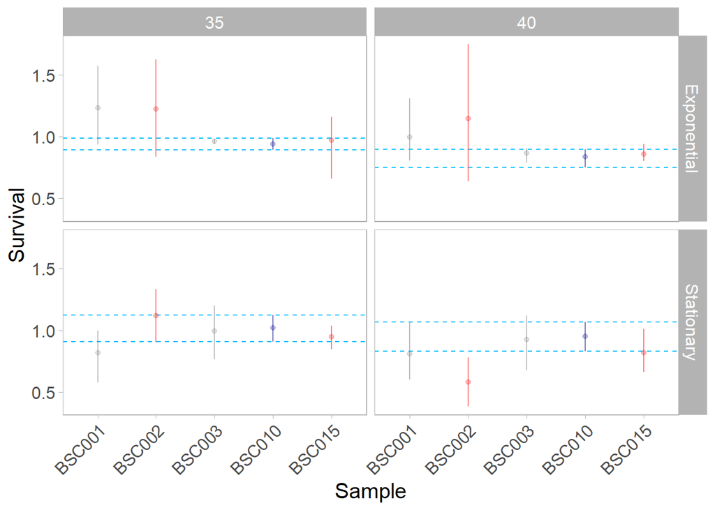

```r
# plot whether the confidence interval of BSC010 is overlapping with the other samples
ggplot(CFU_survival.df %>%
         filter(#Inoculum == "Exponential",
                Species == "P. putida"),
       aes(x = Sample, y = mean_surviv,
           color = Sample)) +
  facet_grid(rows = vars(Inoculum),
             cols = vars(Temp)) +
  # add horizontal dashed lines for BSC010 CIs
  geom_hline(data = CFU_survival.df %>%
               filter(#Inoculum == "Exponential",
                      Sample == "BSC010"),
             aes(yintercept = lwr_ci),
             linetype = "dashed", color = "deepskyblue") +
  geom_hline(data = CFU_survival.df %>%
               filter(#Inoculum == "Exponential",
                      Sample == "BSC010"),
             aes(yintercept = upr_ci),
             linetype = "dashed", color = "deepskyblue") +
  # add data points and their confidence intervals on top
  geom_point(alpha = 0.25, na.rm = TRUE) +
  geom_linerange(aes(ymin = lwr_ci, ymax = upr_ci),
                 alpha = 0.5, na.rm = TRUE, linetype = "solid") +
  scale_color_manual(values = c("BSC010" = "blue4",
                                  "BSC002" = "red",
                                  "BSC015" = "red"),
                       guide = "none") +
  labs(y = "Survival") +
  theme(axis.text.x = element_text(angle = 45, vjust = 1, hjust = 1),
        legend.position = "none")
```

# Plot weird 40C growth by P. protegens

P. protegens showed density-dependent growth at 40C. Growth curves for all strains at all temperatures are given above but below is a plot of P. protegens Pf5 to go in the supplement

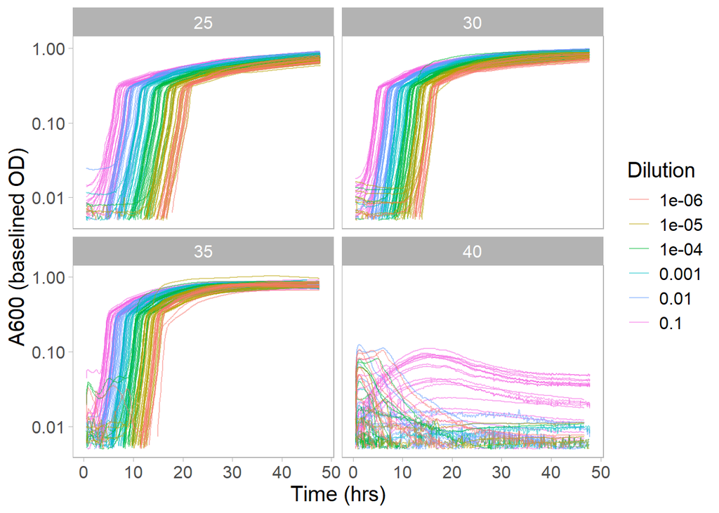

```r
# first let's smooth out the data (we will need to do this for estimating the derivatives anyway)
smoothed_ALL.df <- ALL_data.df %>% ungroup() %>%
                      mutate(smooth_med3 = smooth_data(x = Time,
                                                       y = OD,
                                                       subset_by = uniqID,
                                                       sm_method = "moving-median",
                                                       window_width_n = 3),
                             smoothOD = smooth_data(x = Time,
                                                    y = smooth_med3,
                                                    subset_by = uniqID,
                                                    sm_method = "moving-average",
                                                    window_width_n = 3))
smoothed_ALL.df <- smoothed_ALL.df %>% mutate(smth_baselinedOD = smoothOD - medianBlankOD)

# add the option to keep just the growth curves that were high quality enough to analyze for TTD
  # e.g., exclude growth curves that were inoculated with too few cells
smoothed_ALL.df$Dilution <- as.numeric(levels(smoothed_ALL.df$Dilution))[smoothed_ALL.df$Dilution] # temporarily change class for compatible joining
smoothed_ALL.df <- left_join(smoothed_ALL.df,
                             TTD.df %>% select(Temp, Sample, Dilution, Inoculum, uniqID, Species, TTD_0.05, TTD_0.13))
smoothed_ALL.df$Dilution <- as.factor(smoothed_ALL.df$Dilution) # change back to factor because it's more convenient for plotting

#########################
# plot P. protegens
#########################

temp_data_for_plotting <- rbind(smoothed_ALL.df %>%
                                    filter(Species == "P. protegens",
                                           !is.na(TTD_0.13)),
  # replicates at 40C were excluded from TTD so need to add them back in manually for plotting
                                smoothed_ALL.df %>%
                                    filter(Species == "P. protegens",
                                           Temp == 40))
ggplot(temp_data_for_plotting,
       aes(y = smth_baselinedOD, x = Time, colour = Dilution, group = uniqID)) +
  facet_wrap(vars(Temp)) +
  scale_y_log10(limits=c(0.005,1.1)) +
  geom_line(alpha=0.5) +
  labs(x="Time (hrs)", y="A600 (baselined OD)")
```

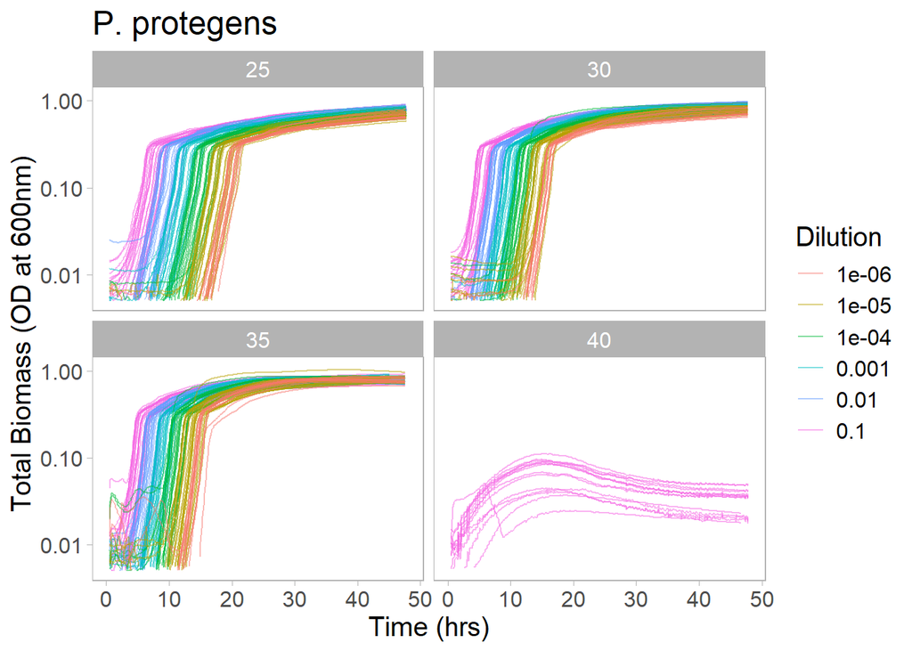

```r
# wells that failed to grow seemed to have had condensation early on
# this obscures the information we are trying to present so let's try to exclude all wells that failed to grow
temp <- temp_data_for_plotting %>% group_by(uniqID, Temp, Dilution, Sample) %>%
          summarise(medOD = median(smth_baselinedOD, na.rm=TRUE))
these_grew <- temp$uniqID[temp$medOD > 0.02]

ggplot(temp_data_for_plotting %>% filter(uniqID %in% these_grew),
       aes(y = smth_baselinedOD, x = Time, colour = Dilution, group = uniqID)) +
  facet_wrap(vars(Temp)) +
  scale_y_log10(limits=c(0.005,1.1)) +
  geom_line(alpha=0.5) +
  labs(x="Time (hrs)", y="Total Biomass (OD at 600nm)", title="P. protegens")
```

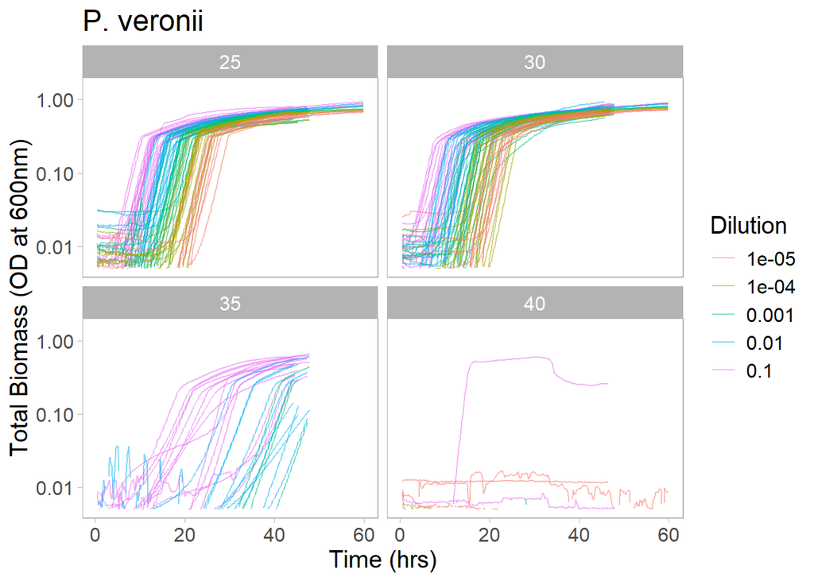

```r
#########################
# for comparison, plot P. veronii
#########################

temp_data_for_plotting <- rbind(smoothed_ALL.df %>%
                                  filter(Species == "P. veronii",
                                         !is.na(TTD_0.05)),
    # replicates at 40C were excluded from TTD so need to add them back in manually for plotting
                                smoothed_ALL.df %>%
                                    filter(Species == "P. veronii",
                                           Temp == 40,
                                           Dilution != "1e-06"))
ggplot(temp_data_for_plotting,
       aes(y = smth_baselinedOD, x = Time, colour = Dilution, group = uniqID)) +
  facet_wrap(vars(Temp)) +
  scale_y_log10(limits=c(0.005,1.5)) +
  geom_line(alpha=0.5) +
  labs(x="Time (hrs)", y="Total Biomass (OD at 600nm)", title="P. veronii")
```

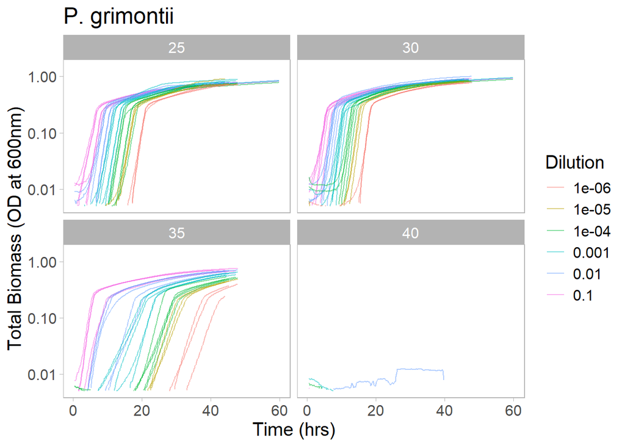

```r
#########################
# for comparison, plot P. grimontii
#########################

temp_data_for_plotting <- rbind(smoothed_ALL.df %>%
                                  filter(Species == "P. grimontii",
                                         !is.na(TTD_0.05)),
    # replicates at 40C were excluded from TTD so need to add them back in manually for plotting
                                smoothed_ALL.df %>%
                                    filter(Species == "P. grimontii",
                                           Temp == 40))
ggplot(temp_data_for_plotting,
       aes(y = smth_baselinedOD, x = Time, colour = Dilution, group = uniqID)) +
  facet_wrap(vars(Temp)) +
  scale_y_log10(limits=c(0.005,1.5)) +
  geom_line(alpha=0.5) +
  labs(x="Time (hrs)", y="Total Biomass (OD at 600nm)", title="P. grimontii")
```

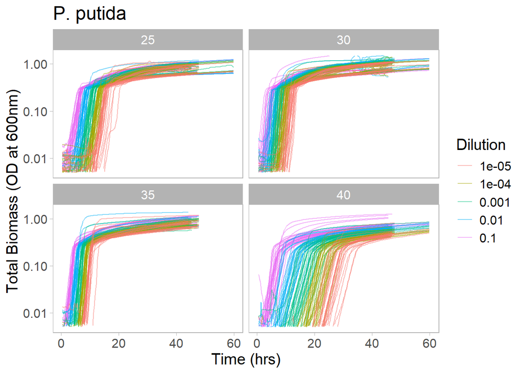

```r
#########################
# finally, plot P. putida
#########################

# P. putida grew well at 40C
# so we plot the data as included in the TTD calculation
temp_data_for_plotting <-   smoothed_ALL.df %>%
                                  filter(Species == "P. putida",
                                         !is.na(TTD_0.05))
ggplot(temp_data_for_plotting,
       aes(y = smth_baselinedOD, x = Time, colour = Dilution, group = uniqID)) +
  facet_wrap(vars(Temp)) +
  scale_y_log10(limits=c(0.005,1.5)) +
  geom_line(alpha=0.5) +
  labs(x="Time (hrs)", y="Total Biomass (OD at 600nm)", title="P. putida")
```

```r
# clean up
rm(temp_data_for_plotting, temp, these_grew)
```

# Plot intraspecific density dependence of growth rate

Estimate the per capita derivative of total biomass. This will allow us to see the intraspecific density dependence of growth rate over time in the batch cultures.

```r
# we've already run the de-noising of the data when we plotted the growth curves above.
derivs.df <- smoothed_ALL.df %>% mutate(percap_deriv = calc_deriv(y = smth_baselinedOD,
                                                                  x = Time,
                                                                  subset_by = uniqID,
                                                                  percapita = TRUE,
                                                                  blank = 0,
                                                                  window_width_n = 5))

# save this intermediate data to output for reproducibility & easy loading in downstream analyses
save(ALL_data.df, TTD.df, Dil_growthrates.df, derivs.df,
     file="all_growthcurve_data.RData")
```

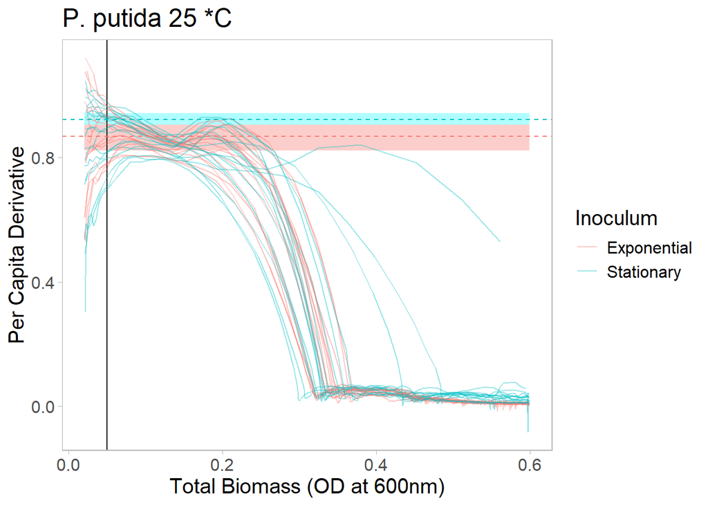

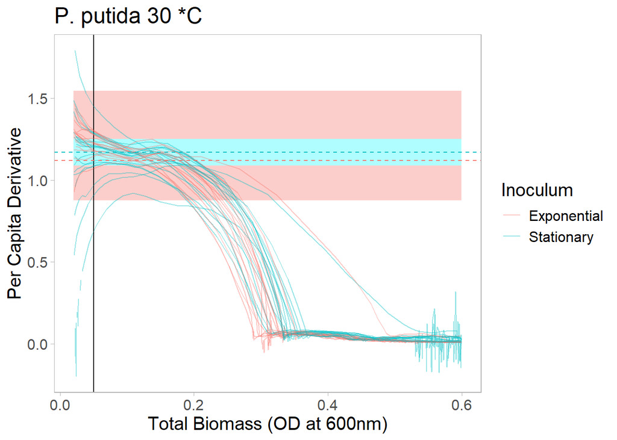

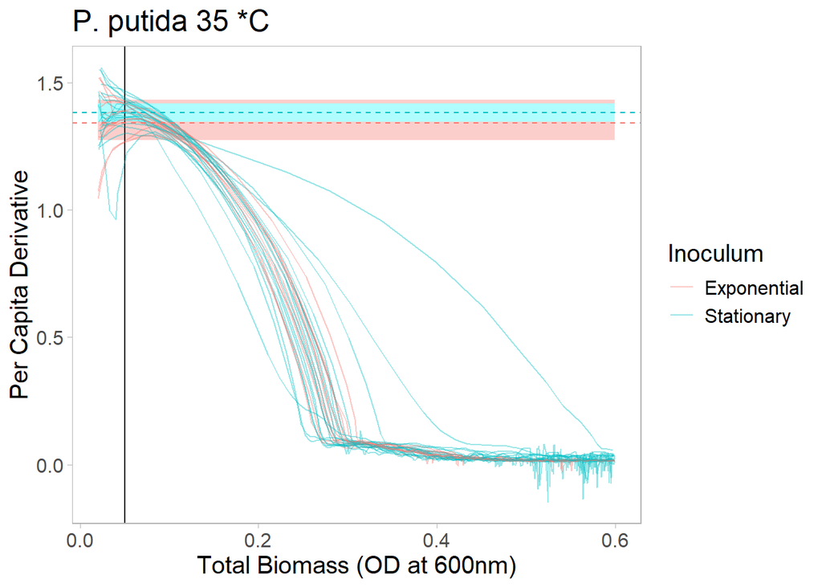

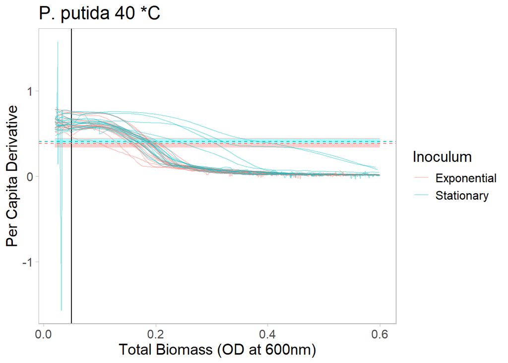

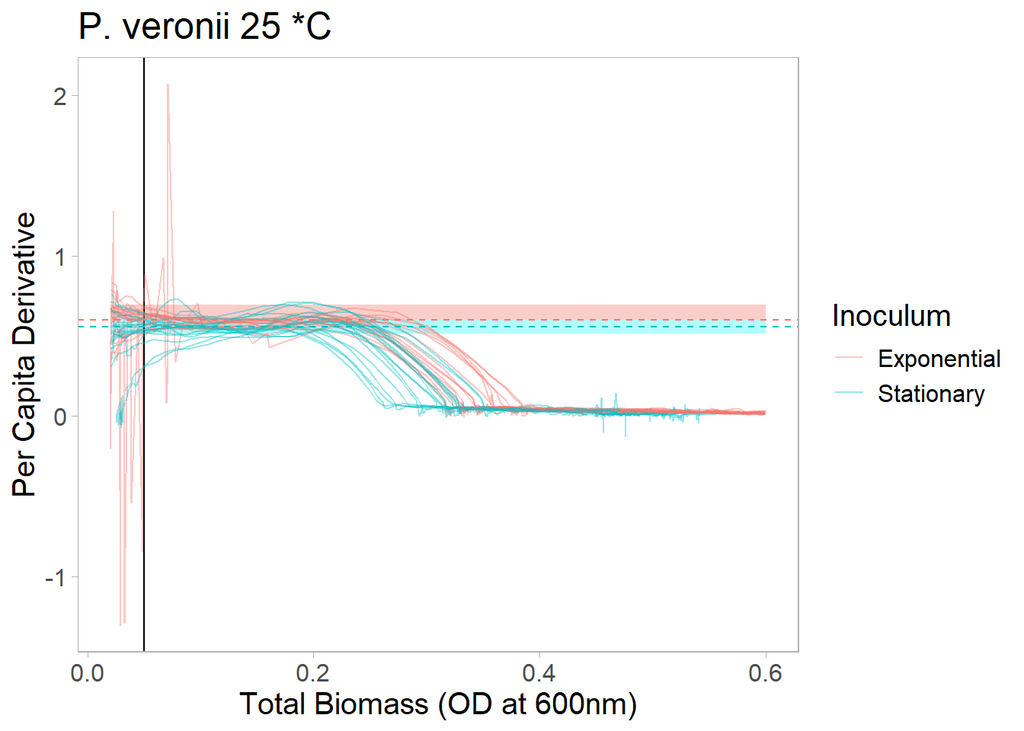

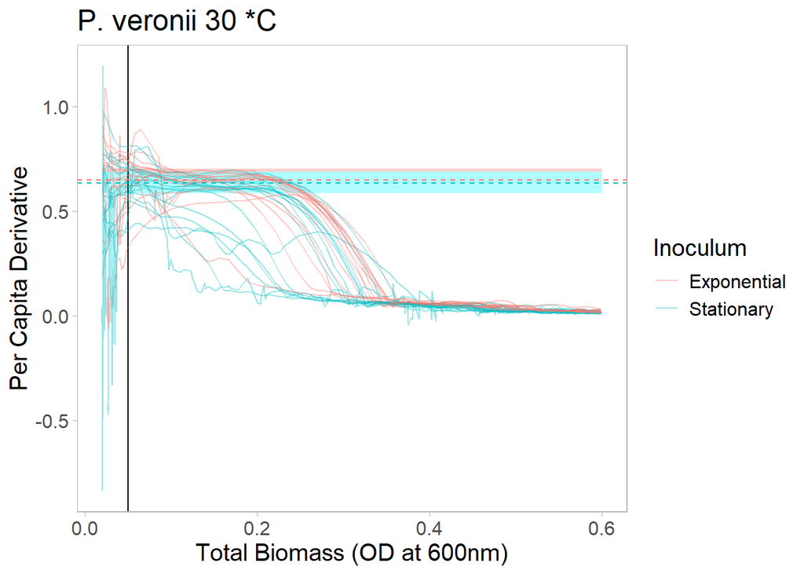

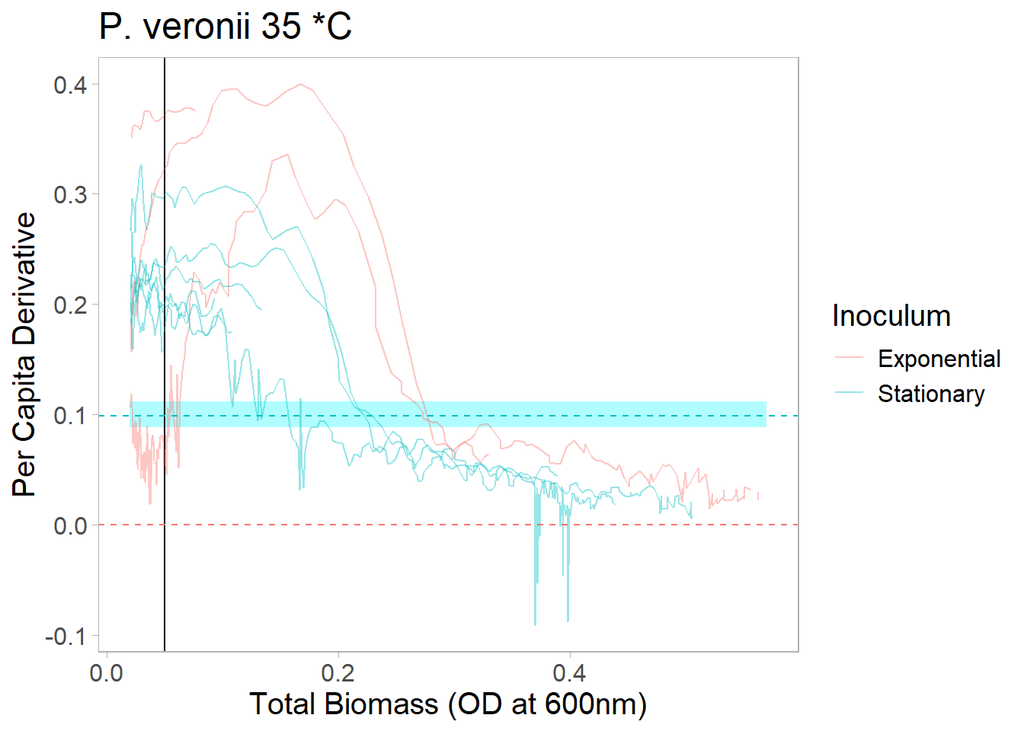

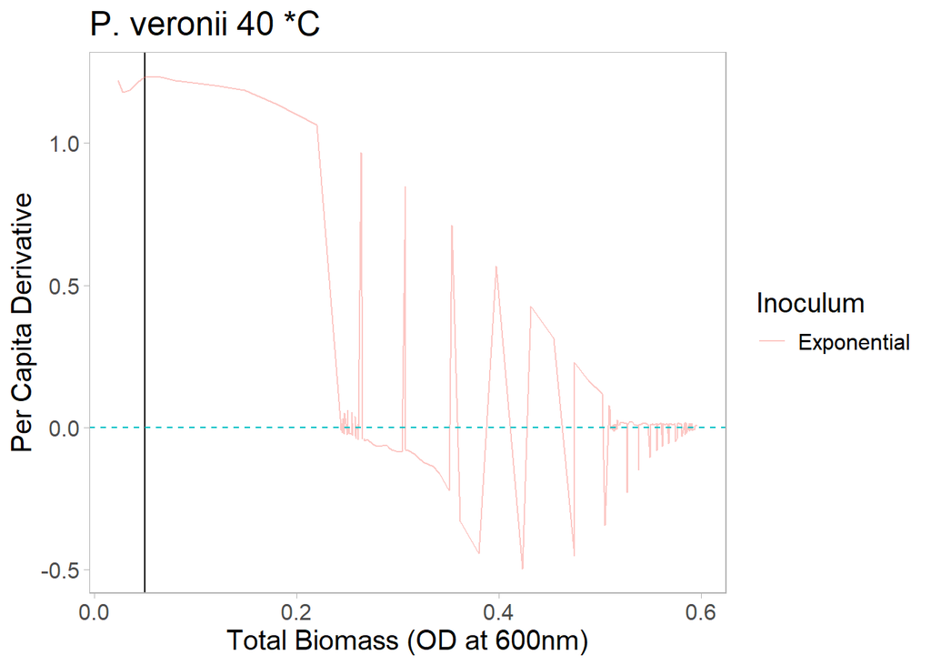

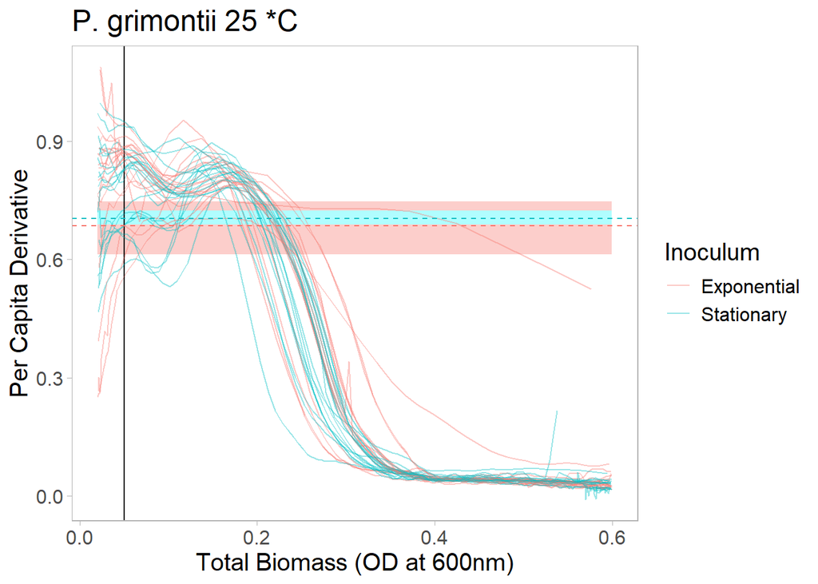

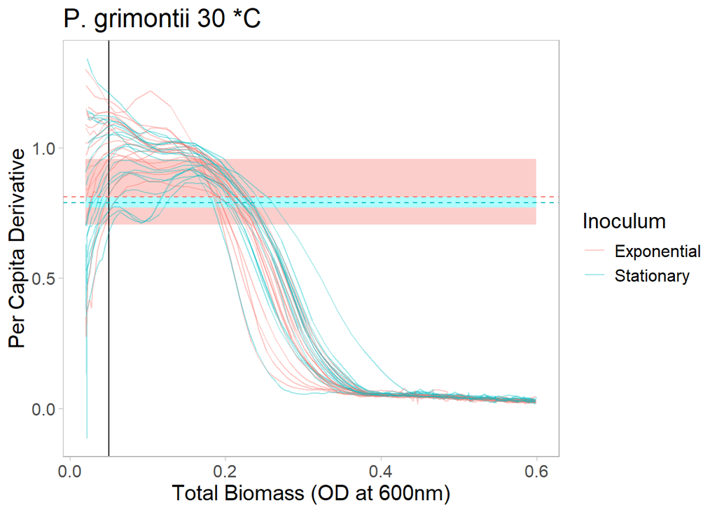

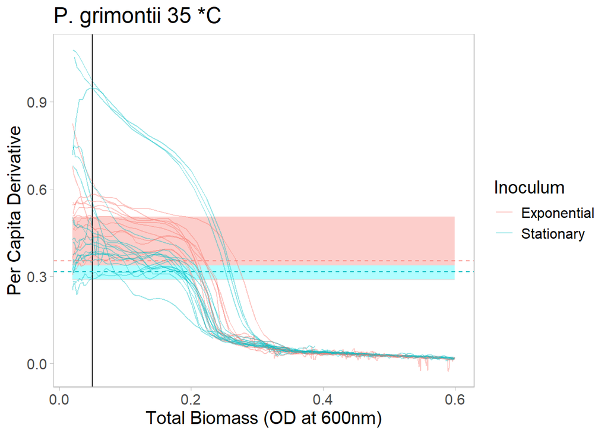

[figure not shown]

[4 more figures not shown]

```r
load("all_growthcurve_data.RData")


for(sam in c("BSC001", "BSC005", "BSC019", "CK101")){
  for(deg in c(25, 30, 35, 40)){
    print(ggplot(derivs.df %>% filter(Sample == sam,
                            Temp == deg,
                            baselinedOD > 0.02,
                            baselinedOD < 0.6),
        aes(x=baselinedOD, y=percap_deriv, colour=as.factor(Inoculum), group = uniqID)) +
        # plot the 95% CI of the intrinsic growth rates as a ribbon
        geom_ribbon(aes(ymin=Dil_growthrates.df$mu_lwrCI[which(Dil_growthrates.df$Sample == sam & Dil_growthrates.df$Temp == deg & Dil_growthrates.df$Inoculum == "Exponential")],
                        ymax=Dil_growthrates.df$mu_uprCI[which(Dil_growthrates.df$Sample == sam & Dil_growthrates.df$Temp == deg & Dil_growthrates.df$Inoculum == "Exponential")]),
                        fill = "#fccecb", colour = NA) +
        # plot the 95% CI of the intrinsic growth rates as a ribbon
        geom_ribbon(aes(ymin=Dil_growthrates.df$mu_lwrCI[which(Dil_growthrates.df$Sample == sam & Dil_growthrates.df$Temp == deg & Dil_growthrates.df$Inoculum == "Stationary")],
                        ymax=Dil_growthrates.df$mu_uprCI[which(Dil_growthrates.df$Sample == sam & Dil_growthrates.df$Temp == deg & Dil_growthrates.df$Inoculum == "Stationary")]),
                        fill = "#b0fdff", colour = NA) +
        # add a vertical line for the threshold of detection (0.05)
        geom_vline(xintercept = 0.05) +
        # plot the derivatives as lines
        geom_line(alpha=0.4) +
        # and plot the intrinsic growth rate estimates from the TTD as dashed lines
        geom_hline(yintercept = Dil_growthrates.df$mu[which(Dil_growthrates.df$Sample == sam & Dil_growthrates.df$Temp == deg & Dil_growthrates.df$Inoculum == "Exponential")],
                   linetype="dashed", colour="#f8766d") +
        geom_hline(yintercept = Dil_growthrates.df$mu[which(Dil_growthrates.df$Sample == sam & Dil_growthrates.df$Temp == deg & Dil_growthrates.df$Inoculum == "Stationary")],
                   linetype="dashed", colour="#00bfc4") +
        labs(title=paste(unique(Dil_growthrates.df$Species[which(Dil_growthrates.df$Sample == sam)]),
                         deg,"*C"),
             colour="Inoculum",
             x = "Total Biomass (OD at 600nm)",
             y = "Per Capita Derivative"))
  }
}
```